# DV_FinalProject

**Authors: Rolando Melendez, Hyunji Seo, Catherine Tu**

## Program file structure

00 Doc - contains .Rmd and .html

01 Data - contains the code to Extract, Transform, and Load our data

03 Tableau Workbooks - this is where the Tableau workbook(s) goes (twbx format)

04 Shiny - contains our workflows and the code for the visualizations along with code used to create Shiny app.

## Data summary and subset

```r
#Shows the subset and summary of the data frame
source("../01 Data/R_ExtractTransform.R", echo = TRUE)
```

```
##
## > require(dplyr)
```

```
##
## > setwd("~/Desktop/Desktop/UT/Fall 2015/Data Visualization/DV_FinalProject/01 Data/CSVs")
##
## > file_path <- "bank-additional.csv"
##
## > df <- rename(read.csv(file_path, stringsAsFactors = FALSE,
## +     sep = ";"), dflt = default)
##
## > names(df) <- toupper(names(df))
##
## > names(df) <- gsub("\\.+", "_", names(df))
##
## > names(df)
##  [1] "AGE"            "JOB"            "MARITAL"        "EDUCATION"
##  [5] "DFLT"           "HOUSING"        "LOAN"           "CONTACT"
##  [9] "MONTH"          "DAY_OF_WEEK"    "DURATION"       "CAMPAIGN"
## [13] "PDAYS"          "PREVIOUS"       "POUTCOME"       "EMP_VAR_RATE"
## [17] "CONS_PRICE_IDX" "CONS_CONF_IDX"  "EURIBOR3M"      "NR_EMPLOYED"
## [21] "Y"
##
## > measures <- c("AGE", "DURATION", "CAMPAIGN", "PDAYS",
## +     "PREVIOUS", "EMP_VAR_RATE", "CONS_PRICE_IDX", "CONS_CONF_IDX",
## +     "EURIBOR3M", "NR_ ..." ... [TRUNCATED]
##
## > for (n in names(df)) {
## +     df[n] <- data.frame(lapply(df[n], gsub, pattern = "[^ -~]",
## +         replacement = ""))
## + }
##
## > dimensions <- setdiff(names(df), measures)
##
## > if (length(measures) > 1 || !is.na(dimensions)) {
## +     for (d in dimensions) {
## +         df[d] <- data.frame(lapply(df[d], gsub, pattern = "[\"']", ..." ... [TRUNCATED]
##
## > if (length(measures) > 1 || !is.na(measures)) {
## +     for (m in measures) {
## +         df[m] <- data.frame(lapply(df[m], gsub, pattern = "[^--.0-9]", .... [TRUNCATED]
##
## > write.csv(df, paste(gsub(".csv", "", file_path), ".reformatted.csv",
```

[output cut: 30 more lines]

```
##  MONTH varchar2(4000),
##  DAY_OF_WEEK varchar2(4000),
##  POUTCOME varchar2(4000),
##  Y varchar2(4000),
##  AGE number(38,4),
##  DURATION number(38,4),
##  CAMPAIGN number(38,4),
##  PDAYS number(38,4),
##  PREVIOUS number(38,4),
##  EMP_VAR_RATE number(38,4),
##  CONS_PRICE_IDX number(38,4),
##  CONS_CONF_IDX number(38,4),
##  EURIBOR3M number(38,4),
##  NR_EMPLOYED number(38,4)
##  );
```

```r
#Shows the subset and summary of the data frame
source("../01 Data/R_ExtractTransformJob.R", echo = TRUE)
```

```
##
## > require(dplyr)
##
## > setwd("~/Desktop/Desktop/UT/Fall 2015/Data Visualization/DV_FinalProject/01 Data/CSVs")
##
## > file_path <- "job-type.csv"
##
## > df <- rename(read.csv(file_path, stringsAsFactors = FALSE,
## +     sep = ","))
##
## > names(df) <- toupper(names(df))
##
## > names(df) <- gsub("\\.+", "_", names(df))
##
## > names(df)
## [1] "JOB_TYPE"       "AVERAGE_SALARY" "HOURS_PER_WEEK"
##
## > measures <- c("AVERAGE_SALARY", "HOURS_PER_WEEK")
##
## > for (n in names(df)) {
## +     df[n] <- data.frame(lapply(df[n], gsub, pattern = "[^ -~]",
## +         replacement = ""))
## + }
##
## > dimensions <- setdiff(names(df), measures)
##
## > if (length(measures) > 1 || !is.na(dimensions)) {
## +     for (d in dimensions) {
## +         df[d] <- data.frame(lapply(df[d], gsub, pattern = "[\"']", ..." ... [TRUNCATED]
##
## > if (length(measures) > 1 || !is.na(measures)) {
## +     for (m in measures) {
## +         df[m] <- data.frame(lapply(df[m], gsub, pattern = "[^--.0-9]", .... [TRUNCATED]
##
## > write.csv(df, paste(gsub(".csv", "", file_path), ".reformatted.csv",
## +     sep = ""), row.names = FALSE, na = "")
##
## > tableName <- gsub(" +", "_", gsub("[^A-z, 0-9, ]",
## +     "", gsub(".csv", "", file_path)))
##
## > sql <- paste("CREATE TABLE", tableName, "(\n-- Change table_name to the table name you want.\n")
##
## > if (length(measures) > 1 || !is.na(dimensions)) {
## +     for (d in dimensions) {
## +         sql <- paste(sql, paste(d, "varchar2(4000),\n"))
## +     }
## + .... [TRUNCATED]
##
## > if (length(measures) > 1 || !is.na(measures)) {
## +     for (m in measures) {
## +         if (m != tail(measures, n = 1))
## +             sql <- paste(sq .... [TRUNCATED]
##
## > sql <- paste(sql, ");")
##
## > cat(sql)
## CREATE TABLE jobtype (
## -- Change table_name to the table name you want.
##  JOB_TYPE varchar2(4000),
##  AVERAGE_SALARY number(38,4),
##  HOURS_PER_WEEK number(38,4)
##  );
```

```r
source("../01 Data/R_Load.R", echo = TRUE)
```

```
##
## > require("jsonlite")
```

```
##
## > require("RCurl")
```

```
##
## > df <- data.frame(fromJSON(getURL(URLencode("skipper.cs.utexas.edu:5001/rest/native/?query=\"select * from BNKMKTG\""),
## +     httpheader = c(DB = "j ..." ... [TRUNCATED]
##
## > head(df)
##          JOB  MARITAL        EDUCATION DFLT HOUSING LOAN   CONTACT MONTH
## 1 bluecollar  married          basic9y   no     yes   no  cellular   may
## 2      admin  married          unknown   no     yes   no telephone   apr
## 3   services  married       highschool   no     yes   no  cellular   apr
## 4 bluecollar divorced          basic6y   no     yes   no  cellular   may
## 5      admin   single universitydegree   no     yes   no  cellular   jul
## 6 technician divorced          unknown   no     yes  yes  cellular   oct
##   DAY_OF_WEEK    POUTCOME   Y AGE DURATION CAMPAIGN PDAYS PREVIOUS
## 1         wed nonexistent  no  37      204        2   999        0
## 2         wed     success yes  52      403        1     6        1
## 3         mon nonexistent  no  46      180        1   999        0
## 4         wed nonexistent  no  42       16        2   999        0
## 5         mon nonexistent  no  35      447        3   999        0
## 6         thu nonexistent  no  49       81        1   999        0
##   EMP_VAR_RATE CONS_PRICE_IDX CONS_CONF_IDX EURIBOR3M NR_EMPLOYED
## 1         -1.8         92.893         -46.2     1.334      5099.1
## 2         -1.8         93.749         -34.6     0.654      5008.7
## 3         -1.8         93.075         -47.1     1.405      5099.1
## 4         -1.8         92.893         -46.2     1.281      5099.1
## 5          1.4         93.918         -42.7     4.960      5228.1
## 6         -3.4         92.431         -26.9     0.754      5017.5
##
## > summary(df)
##          JOB           MARITAL                  EDUCATION
##  admin     :1012   divorced: 446   universitydegree  :1264
##  bluecollar: 884   married :2509   highschool        : 921
##  technician: 691   single  :1153   basic9y           : 574
##  services  : 393   unknown :  11   professionalcourse: 535
##  management: 324                   basic4y           : 429
##  retired   : 166                   basic6y           : 228
##  (Other)   : 649                   (Other)           : 168
##       DFLT         HOUSING          LOAN           CONTACT
##  no     :3315   no     :1839   no     :3349   cellular :2652
##  unknown: 803   unknown: 105   unknown: 105   telephone:1467
##  yes    :   1   yes    :2175   yes    : 665
```

[output cut: 21 more lines]

```
##  Min.   :-3.40000   Min.   :92.20   Min.   :-50.8   Min.   :0.635
##  1st Qu.:-1.80000   1st Qu.:93.08   1st Qu.:-42.7   1st Qu.:1.334
##  Median : 1.10000   Median :93.75   Median :-41.8   Median :4.857
##  Mean   : 0.08497   Mean   :93.58   Mean   :-40.5   Mean   :3.621
##  3rd Qu.: 1.40000   3rd Qu.:93.99   3rd Qu.:-36.4   3rd Qu.:4.961
##  Max.   : 1.40000   Max.   :94.77   Max.   :-26.9   Max.   :5.045
##
##   NR_EMPLOYED
##  Min.   :4964
##  1st Qu.:5099
##  Median :5191
##  Mean   :5166
##  3rd Qu.:5228
##  Max.   :5228
##
```

## Label Explanations:

AGE - The age of each marketing participant

JOB - Type of job

MARITAL - Marital Status

EDUCATION - Level of education reached by participant

DEFAULT - Has this participant defaulted before

HOUSING - Does this participant have a housing loan (Mortgage)

LOAN - Does this participant have a personal loan

CONTACT - Contact communication type (cellular or telephone)

MONTH - Last contact month of the year

DAY OF WEEK - Last contact day of the week

DURATION - Duration of the last contact to the participant

CAMPAIGN - Number of times this participant was contacted during this campaign

PDAYS - Number of days since participant was last contacted

PREVIOUS - Number of times this participant was contacted before this campaign

POUTCOME - Outcome of previous marketing campaign

EMP VAR RATE - Employment variation rate

CONS PRICE IDX - Consumer price index

CONS CONF IDX - Consumer confidence index

EURIBOR3M - Rate at which banks lend to each other; 3 month loans

NR EMPOLOYED - Number of employees

Y - Outcome, Did the participant subscribe to a term deposit

## Non_Aggregated Measures Analysis:

#### Boxplot:

1. From the Analysis tab de-select Aggregate Measures.
2. Select AGE in Measures, Click on Box-and-whisker plot in “Show Me”.
3. Drag EDUCATION from Dimensions onto Rows.
4. Drag Y from Dimensions onto Rows, after EDUCATION.
5. Add EDUCATION to Filter, Filter out “Illiterate” and “Unknown”.

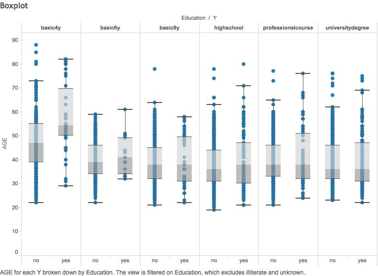

## Aggregrated Measures Analysis:

#### Histogram:

1. Right-click AGE in Measures. Click Create>Bins…. Change the Size of Bins to be 8. Click OK.
2. Drag AGE (bin) to Columns.
3. Drag AGE to Rows. Right click on it, click on Measure, and change to Count.
4. Drag Campaign to Rows. Right click on it, click on Measure, and change to Sum.
5. Add Y to Filter. Right-click on Y and click “Show Quick Filter”

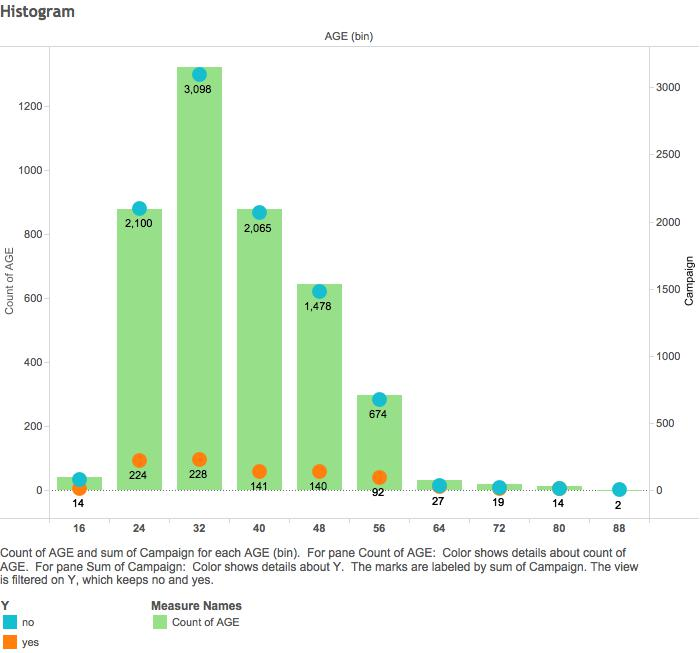

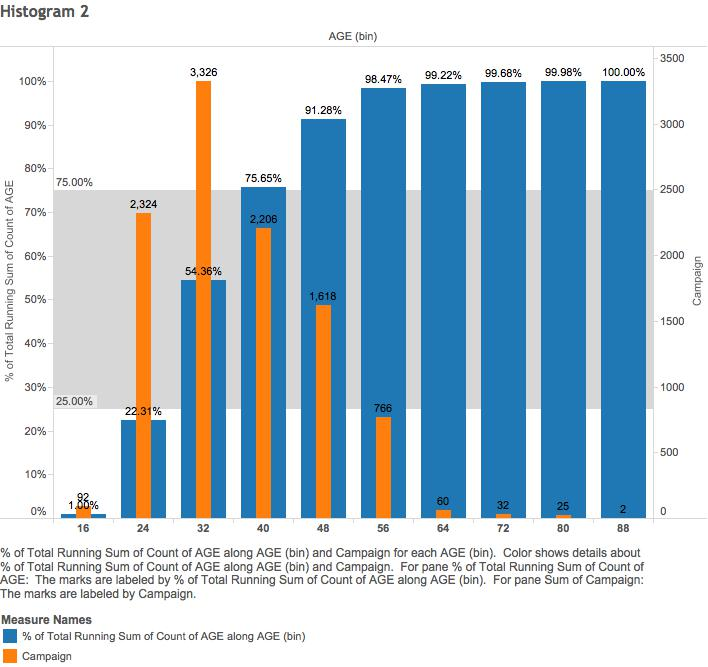

## Scatter Plots:

#### CPI Scatter Plot:

1. From the Analysis tab de-select Aggregate Measures.
2. Drag DURATION from Measures onto Columns.
3. Drag CONS PRICE IDX from Measures onto Rows.
4. Right Click the Y-Axis and select Edit Axis.
5. Set to a fixed range of 92-95.
6. Drag Y from Dimensions onto Color.
7. From the Analysis tab select Trend Lines>Show Trend Lines.
8. From the Analysis tab select Trend Lines>Edit Trend Lines and uncheck “Show confidence bands”.

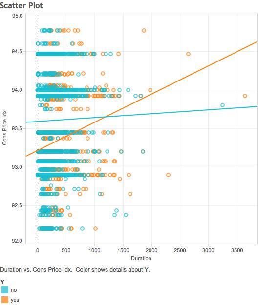

#### Duration Percentile Scatter Plot:

1. From the Analysis tab de-select Aggregate Measures.
2. Drag DURATION from Measures onto Columns.
3. Drag Y from Dimensions onto Rows.
4. Drag POUTCOME from Dimensions onto Rows, after Y.
5. Drag Y from Dimensions onto Color.

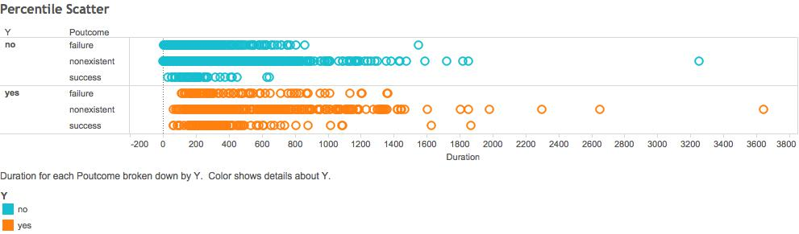

## Crosstabs:

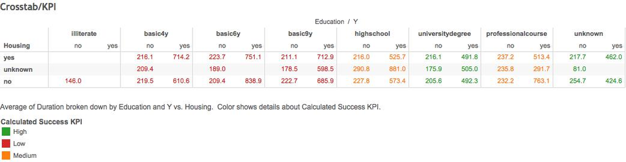

## Barcharts:

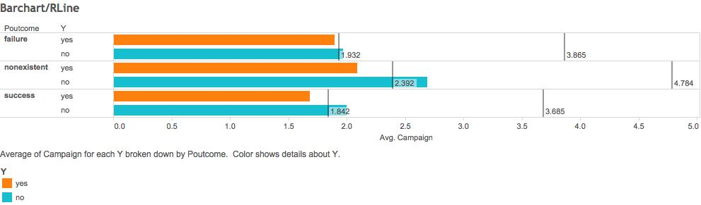

#### Number of Campaigns by Past and Current Outcome:

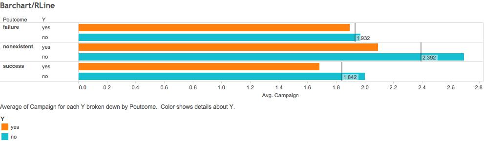

In this visualization we observed the number of times each person was contacted in the current cmpaign (CAMPAIGN), past campaign outcome (POUTCOME), and current campaign outcome (Y).

We found that for those who had previously declined taking a long-term bank deposit, there was a small difference in the average number of campaigns between those who accepted or declined the bank deposit for this current bank marketing. For those who had previously accepted taking a long-term bank deposit, there was a greater difference in the average number of campaigns between those who accepted or declined the bank deposit for this current bank marketing.

*Also demonstrates data blending*

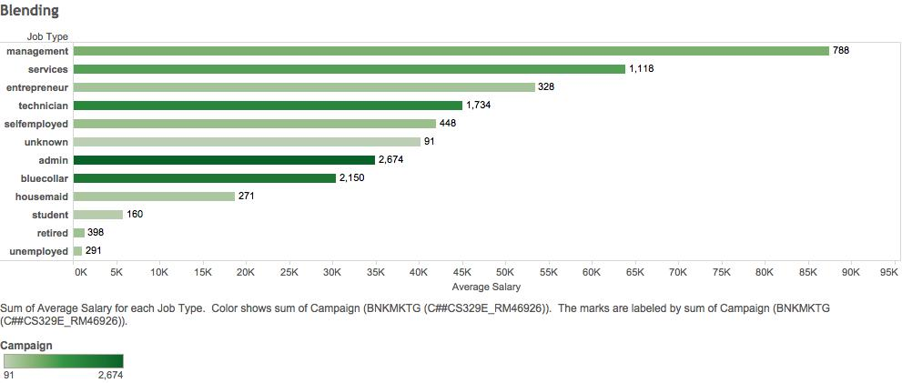

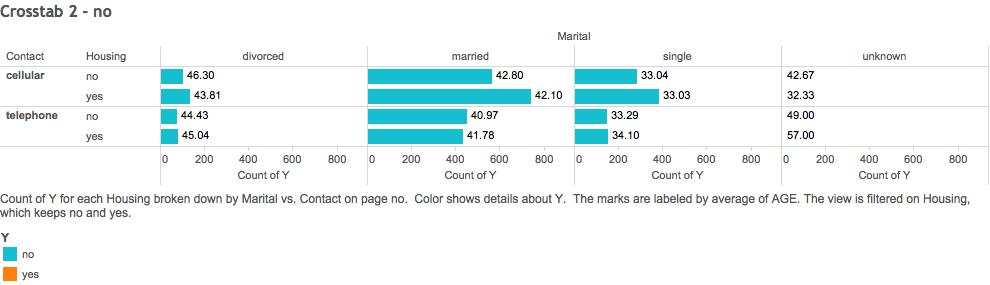

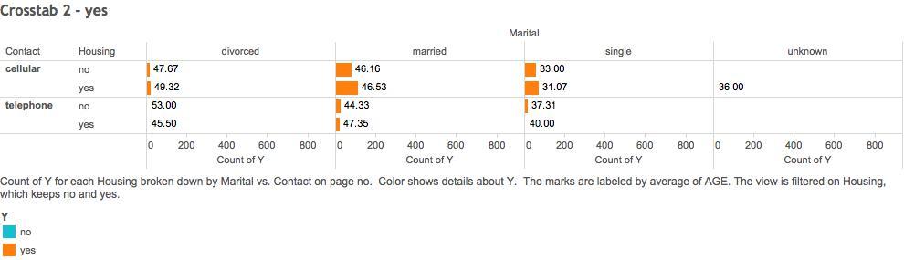